# Consumer Expenditure Analysis

Kaile Phelps

2023-10-06

# Consumer Expenditure Survey Analysis

The purpose of this analysis is to investigate trends and changes in consumer spending for different age demographics during and after the COVID pandemic lockdowns. The data has been taken from the Bureau of Labor Statistics’ (BLS) [Consumer Expenditure Survey](https://www.bls.gov/cex/).

## Data Collection

I have collected the data using the recommended API from the [BLS website](https://www.bls.gov/developers/). I have stored the code related to pulling and wrangling the data into a csv in this [repository](https://github.com/kphelps-hub/Consumer-Expenditure-Survey/blob/main/Data%20Retrieval.R).

There is far more information that is tracked in the Customer Expenditure Survey than I could possibly breakdown and analyze, so for the purpose of this project I wanted to keep it high level and look at the primary 14 categories of spending and broken down by age ranges. To generate more precise analysis would require delving further into some of the breakdowns of the survey.

## Loading and Cleaning the Data

To begin the analysis, we will first need to load the necessary packages. This analysis will primarily be using the tidyverse, ggplot2, and reshape2 packages.

```r
library(tidyverse)
library(ggplot2)
library(reshape2)
```

We will then go ahead and read in the csv and add descriptions to the characterstic code and item codes from the data. To validate that the columns have been created successfully I printed the first few lines of the data frame with the columns that we added. The values can be confirmed based on the glossary of the customer expenditure survey.

```r
#Read data
data <- read.csv("2023_Consumer_Exp_Data.csv")
chr_code = 1:9
chr_code_desc = c("All Consumer Units",
                  "Reference person under age 25",
                  "Reference person from age 25 to 34",
                  "Reference person from age 35 to 44",
                  "Reference person from age 45 to 54",
                  "Reference person from age 55 to 64",
                  "Reference person from age 65 or over",
                  "Reference person from age 65 to 74",
                  "Reference person from age 75 or over")
chr_code_mapping <- data.frame(chr_code,chr_code_desc)

item_code = c("ALCBEVG",
                  "APPAREL",
                  "CASHCONT",
                  "EDUCATN",
                  "ENTRTAIN",
                  "FOODTOTL",
                  "HEALTH",
                  "HOUSING",
                  "INSPENSN",
                  "MISC",
                  "PERSCARE",
                  "READING",
                  "TOBACCO",
                  "TOTALEXP",
                  "TRANS")
item_code_desc = c("Alcoholic beverages",
                    "Apparel and services",
                    "Cash contributions",
                    "Education",
                    "Entertainment",
                    "Food",
                    "Healthcare",
                    "Housing",
                    "Personal insurance and pensions",
                    "Miscellaneous expenditures",
                    "Personal care products and services",
                    "Reading",
                    "Tobacco products and smoking supplies",
                    "Total average annual expenditures",
                    "Transportation")

#add my own short description
item_code_short_desc = c("Alcohol",
                    "Apparel",
                    "Contributions",
                    "Education",
                    "Entertainment",
                    "Food",
                    "Healthcare",
                    "Housing",
                    "Personal insurance",
                    "Miscellaneous",
                    "Personal care",
                    "Reading",
                    "Tobacco",
                    "Total",
                    "Transportation")
item_code_mapping <- data.frame(item_code,item_code_desc,item_code_short_desc)

#join data with item code mapping to include descriptions
data <- data %>%
  left_join(chr_code_mapping, by = 'chr_code') %>%
  left_join(item_code_mapping, by = 'item_code')

head(data[,c("chr_code","chr_code_desc","item_code","item_code_desc","item_code_short_desc")])
```

```
##   chr_code      chr_code_desc item_code      item_code_desc
## 1        1 All Consumer Units   ALCBEVG Alcoholic beverages
## 2        1 All Consumer Units   ALCBEVG Alcoholic beverages
## 3        1 All Consumer Units   ALCBEVG Alcoholic beverages
## 4        1 All Consumer Units   ALCBEVG Alcoholic beverages
## 5        1 All Consumer Units   ALCBEVG Alcoholic beverages
## 6        1 All Consumer Units   ALCBEVG Alcoholic beverages
##   item_code_short_desc
## 1              Alcohol
## 2              Alcohol
## 3              Alcohol
## 4              Alcohol
## 5              Alcohol
## 6              Alcohol
```

Before going any further, we should validate the structure of the data is correct.

```r
str(data)
```

```
## 'data.frame':    1080 obs. of  13 variables:
##  $ year                : int  2022 2021 2020 2019 2018 2017 2016 2015 2022 2021 ...
##  $ period              : chr  "A01" "A01" "A01" "A01" ...
##  $ periodName          : chr  "Annual" "Annual" "Annual" "Annual" ...
##  $ latest              : chr  "true" NA NA NA ...
##  $ value               : chr  "583" "554" "478" "579" ...
##  $ series_id           : chr  "CXUALCBEVGLB0401M" "CXUALCBEVGLB0401M" "CXUALCBEVGLB0401M" "CXUALCBEVGLB0401M" ...
##  $ chr_code            : int  1 1 1 1 1 1 1 1 2 2 ...
##  $ item_code           : chr  "ALCBEVG" "ALCBEVG" "ALCBEVG" "ALCBEVG" ...
##  $ footnote_code       : int  NA NA NA NA NA NA NA NA NA NA ...
##  $ footnote_text       : chr  NA NA NA NA ...
##  $ chr_code_desc       : chr  "All Consumer Units" "All Consumer Units" "All Consumer Units" "All Consumer Units" ...
##  $ item_code_desc      : chr  "Alcoholic beverages" "Alcoholic beverages" "Alcoholic beverages" "Alcoholic beverages" ...
##  $ item_code_short_desc: chr  "Alcohol" "Alcohol" "Alcohol" "Alcohol" ...
```

This gives us an overview of the type of data that we have available. We have breakdowns by year, spending category (item_code), and age group (chr_code). For each of these there is a “value” column representing the amount that was spent for that particular breakdown. We can also see that the “value” field is a “chr” type rather than an “int”. So we will need to change the data type of the column.

```r
data$value <- as.integer(data$value)
```

```
## Warning: NAs introduced by coercion
```

When doing so, there is a warning saying that NAs were introduced. Reviewing the footnotes for these particular lines show that the data is not within the necessary margin of error for the survey, so NAs are appropriate.

```r
data %>%
  filter(is.na(value)) %>%
  select(year,chr_code_desc,item_code_desc,footnote_text)
```

```
##   year                        chr_code_desc             item_code_desc
## 1 2022        Reference person under age 25         Cash contributions
## 2 2022 Reference person from age 75 or over         Cash contributions
## 3 2022   Reference person from age 65 to 74                  Education
## 4 2022 Reference person from age 75 or over                  Education
## 5 2022        Reference person under age 25 Miscellaneous expenditures
## 6 2022        Reference person under age 25                    Reading
##                                                                                                                                                                        footnote_text
## 1 Data are suppressed due to the Relative Standard Error (RSE) being equal to or greater than 25 percent. See www.bls.gov/cex/tables-getting-started-guide.htm for more information.
## 2 Data are suppressed due to the Relative Standard Error (RSE) being equal to or greater than 25 percent. See www.bls.gov/cex/tables-getting-started-guide.htm for more information.
## 3 Data are suppressed due to the Relative Standard Error (RSE) being equal to or greater than 25 percent. See www.bls.gov/cex/tables-getting-started-guide.htm for more information.
## 4 Data are suppressed due to the Relative Standard Error (RSE) being equal to or greater than 25 percent. See www.bls.gov/cex/tables-getting-started-guide.htm for more information.
## 5 Data are suppressed due to the Relative Standard Error (RSE) being equal to or greater than 25 percent. See www.bls.gov/cex/tables-getting-started-guide.htm for more information.
## 6 Data are suppressed due to the Relative Standard Error (RSE) being equal to or greater than 25 percent. See www.bls.gov/cex/tables-getting-started-guide.htm for more information.
```

Finally, we are going to drop some columns that are not related to the analysis such as footnote, period and latest.

```r
#remove columns
data <- data %>%
  select(-c(period,
            periodName,
            footnote_code,
            footnote_text,
            latest))
```

With that our dataset is ready to be used for our analysis.

## Data Analysis

### Total Consumer Spending

The first piece that I want to look at is just how total spending has changed over time as that will give context when looking at how spending has changed within specific categories.

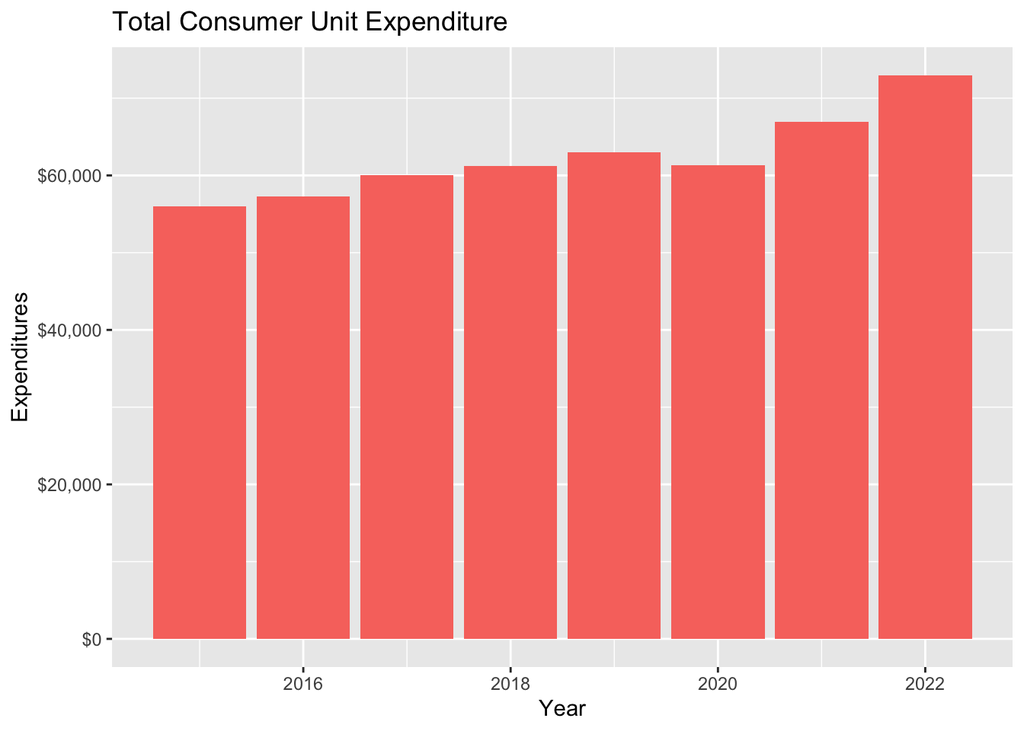

```r
#Total Spending Plot
spending_plot <- ggplot(data = data %>%
         filter(chr_code == 1,
                item_code == 'TOTALEXP'))+
  geom_col(mapping = aes(x=year,
                         y = value),
           fill = rep("#F8766D",8))+
  labs(title = "Total Consumer Unit Expenditure",
       y = "Expenditures",
       x = "Year")+
  scale_y_continuous(labels = scales::label_dollar(prefix = "$", big.mark = ","))

print(spending_plot)
```

The first piece that stands out is that dip in 2020 during the most severe part of the lockdown. Since we are analyzing trends in spending, it is worth creating a new column for the percent change year to year. We will go ahead and create this below. To validate the results and to see the percent changes I will print the results below.

```r
#create % growth field
data <- data %>%
  group_by(series_id) %>%
  arrange(year, .by_group = TRUE) %>%
  mutate (pct_change = (value-lag(value))/lag(value)*100,
          amount_change = value-lag(value)) %>%
  ungroup()

#Print % Change for Total Expenditures
data %>%
  filter(chr_code==1,
         item_code == 'TOTALEXP') %>%
  select(year,
         value,
         pct_change)
```

```
## # A tibble: 8 × 3
##    year value pct_change
##   <int> <int>      <dbl>
## 1  2015 55978      NA
## 2  2016 57311       2.38
## 3  2017 60060       4.80
## 4  2018 61224       1.94
## 5  2019 63036       2.96
## 6  2020 61332      -2.70
## 7  2021 66928       9.12
## 8  2022 72967       9.02
```

Looking at the data in the table we can see the only negative year is in 2020 and it is immediately followed up by 2 years of the strongest growth. Just looking at this table does not give enough information to deduce whether there is new growth in spending beyond what we would have expected pre-pandemic or if the recent years of growth are just a “catch-up” to our previous trajectory. To investigate this further, I will create a log-linear model based on the years leading up to 2020.

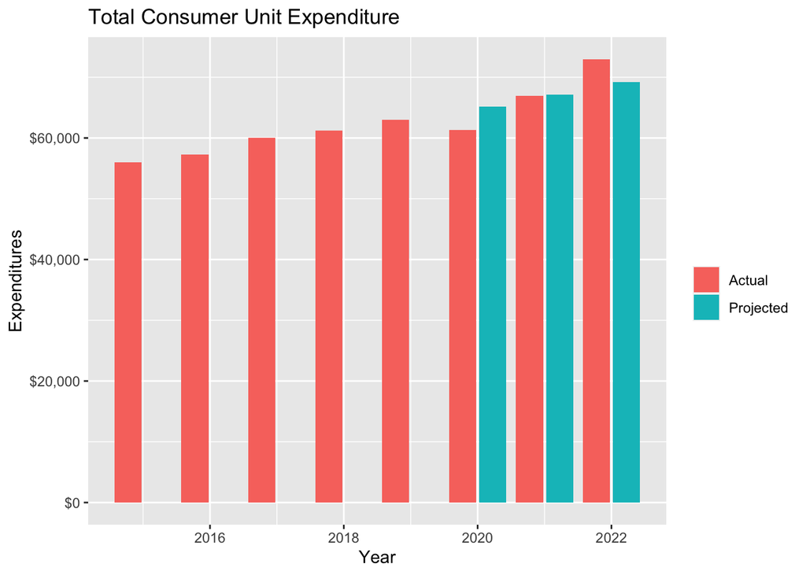

```r
#suppress chunk warning because first 5 years of the projection are NA
#filter data to just pre-pandemic for total spending
pre_pandemic_data <- data %>%
  filter(chr_code == 1,
         item_code == 'TOTALEXP',
         year < 2020)

#create linear regression model based on log(value) ~ year
model <- lm(log(value) ~ year,
            data = pre_pandemic_data)

#data frame to store projections
projection <- data.frame(
  year = 2020:2022
  )
projection$projected_value <- exp(predict(model, newdata = projection))

#data frame for new plot. Joining projection with actual data,
#then using the melt function to switch to long data to create column chart
projection_plot_data <- data %>%
  filter(chr_code ==1,
         item_code == 'TOTALEXP') %>%
  select(year,
         value) %>%
  left_join(projection, by = "year") %>%
  rename(Actual = value,
         Projected = projected_value) %>%
  melt(id.vars = 'year')

#Plot projections alongside actual data
projected_spending <- ggplot(data = projection_plot_data)+
         geom_col(mapping = aes(x = year,
                           y = value,
                           fill = variable),
                  position = position_dodge2())+
    labs(title = "Total Consumer Unit Expenditure",
       y = "Expenditures",
       x = "Year",
       fill = "")+
  scale_y_continuous(labels = scales::label_dollar(prefix = "$", big.mark = ","))

print(projected_spending)
```

From this chart, we can clearly see the dip in spending versus the projection in 2020, but by 2021 spending had essentially caught back up to the projection and 2022 had surpassed it. Based on this, there does not appear to be evidence of a trend of limited spending, if anything, this is evidence of the opposite. Coming out of the pandemic people are increasing their spending more quickly than before. Whether or not this continues into 2023 and beyond will be interesting to see. As of right now 2022 could be an outlier and we are course correcting back on track or there may be a more rapid rate of growth in spending.

### Spending By Category

The next area that I am going to be analyzing is spending by category to see which categories of spending were more susceptible to change during the pandemic than others. To begin, we can look at a graph of the 14 categories

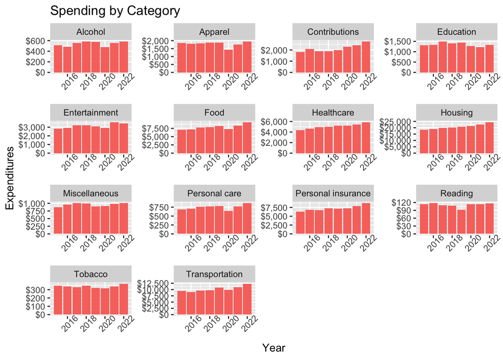

```r
#Chart of all categories over time
ggplot(data = data %>%
         filter(chr_code==1,
                item_code!='TOTALEXP'))+
  geom_col(mapping = aes(x = year,
                         y = value),
           fill = "#F8766D")+
  facet_wrap(~item_code_short_desc, scales = "free")+
  theme(axis.text.x = element_text(angle = 45))+
  labs(title = "Spending by Category",
       x = "Year",
       y = "Expenditures")+
  scale_y_continuous(labels = scales::label_dollar(prefix = "$", big.mark = ","))
```

We can see from the above graphs that for most categories, there is a decent decrease in spending in 2020 and a subsequent strong increase in the last two years. Housing, Healthcare, and Personal Insurance are outliers when it comes to this trend, but that makes sense since those categories we would expect to be more inelastic than the Transportation or Food cateogries. To see which categories suffered the largest setback in 2020, I will take a look at just the percent changes from that year.

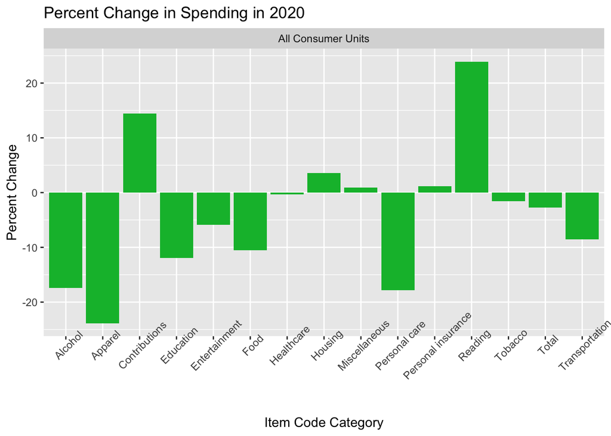

```r
#now let's create a chart just looking at 2020
data %>%
  filter(year == '2020',
         chr_code %in% c(1)) %>%
  ggplot()+
  geom_col(mapping = aes(x = item_code_short_desc,
                         y = pct_change),
           fill = "#00BA38")+
  facet_wrap(~chr_code_desc)+
  theme(axis.text.x = element_text(angle = 45))+
  labs(title = "Percent Change in Spending in 2020",
        y = "Percent Change",
       x = "Item Code Category")
```

This confirms the trends mentioned above with the Housing and Healthcare and Personal Insurance all increasing or staying the same while spending in about half of the remaining categories decreased substantially. If we were to remove those 3 categories and really focus on the more “discretionary” spending then we can get a better sense of how consumer’s actively changed their purchasing habits in 2020.

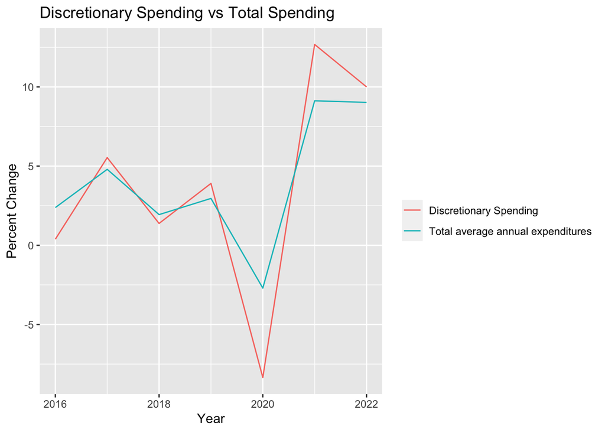

```r
disc_spending <- data %>%
  filter(!item_code %in% c("HEALTH",
                           "HOUSING",
                           "INSPENSN",
                           "TOTALEXP"),
         chr_code == 1) %>%
  group_by(year,chr_code,chr_code_desc) %>%
  summarise(value = sum(value), .groups = "keep") %>%
  ungroup() %>%
  group_by(chr_code,chr_code_desc) %>%
  arrange(year, .by_group = TRUE) %>%
  mutate(pct_change = (value-lag(value))/lag(value)*100,
         item_code_desc = 'Discretionary Spending')

total_spending <- data %>%
  filter(chr_code == 1,
         item_code == 'TOTALEXP') %>%
  select(year,
         chr_code,
         chr_code_desc,
         value,
         pct_change,
         item_code_desc) %>%
  rbind(disc_spending) %>%
  filter(year > 2015)

disc_spending <- ggplot(total_spending)+
  geom_line(mapping = aes(x = year,
                         y = pct_change,
                         color = item_code_desc))+
  labs(title = "Discretionary Spending vs Total Spending",
       y = "Percent Change",
       x = "Year",
       color = "")

print(disc_spending)
```

Looking at just the discretionary spending shows that consumers spent about 8% less in these categories despite just an overall drop of less than 3% in total spending. We can also see that the discretionary spending increased more than total spending in 2021 and 2022, though it is much more closely aligned with overall spending in 2022. This does seem to indicate that some amount of the increase in spending in 2022 is likely due to increased costs of living or inflation.

### Transportation by Age

In this next section I wanted to look specifically into trends within the field of transportation. Given major restrictions on travel due to the pandemic, but also an increase in the amount of remote work flexibility, this seemed like an area that would have some interesting trends. First, I just wanted to look at a quick breakdown across the age groups spending on transportation.

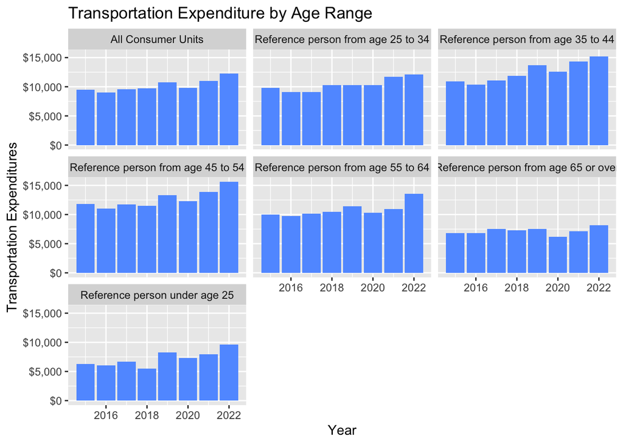

```r
#Transportation by age group
data %>%
  filter(item_code == 'TRANS',
         !chr_code %in% c(8,9)) %>%
  ggplot()+
  geom_col(mapping = aes(x = year,
                         y = value),
           fill = "#619CFF")+
  facet_wrap(~chr_code_desc)+
  labs(title = "Transportation Expenditure by Age Range",
        y = "Transportation Expenditures",
       x = "Year")+
  scale_y_continuous(labels = scales::label_dollar(prefix = "$", big.mark = ","))
```

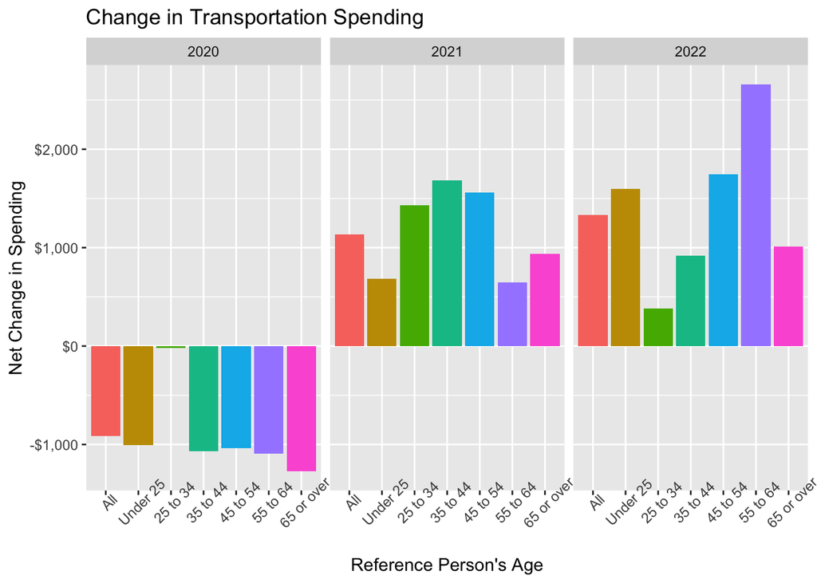

```r
#Year over year change by age group
trans_spending <- ggplot(data %>%
         filter(!chr_code %in%c(8,9),
                item_code == 'TRANS',
                year > 2019))+
  geom_col(mapping = aes(x = as.factor(chr_code),
                         y = amount_change,
                         fill = as.factor(chr_code)))+
  facet_wrap(~year)+
  scale_x_discrete(labels = c("1" = "All",
                              "2" = "Under 25",
                              "3" = "25 to 34",
                              "4" = "35 to 44",
                              "5" = "45 to 54",
                              "6" = "55 to 64",
                              "7" = "65 or over"))+
  theme(axis.text.x = element_text(angle = 45),
        legend.position = "none")+
  labs(title = "Change in Transportation Spending",
        y = "Net Change in Spending",
        x = "Reference Person's Age")+
  scale_y_continuous(labels = scales::label_dollar(prefix = "$", big.mark = ","))

print(trans_spending)
```

### Expenditure Restructuring

Finally, perhaps the most important thing to look as is if there is significant change in how much fluctuation there is between categories. Rather than looking at the total amount increase or decrease, I wanted to see if people’s consumption patterns were shifting significantly. To do that, I took the year over year difference in spending per category and summed up the absolute values. This provided me with a measure of changes in spending over time. I will be labelling this column as “restructured expenditures”

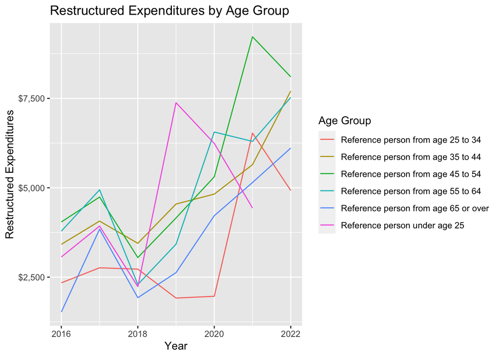

```r
#warning suppressed as there was missing data for the youngest category

#Create absolute change in each category
data <- data %>%
  group_by(series_id) %>%
  arrange(year, .by_group = TRUE) %>%
  mutate(abs_change = abs(value-lag(value)))

#Group data by year and age group
#Summing the absolute changes in each category
grouped_data <- data %>%
  filter(!chr_code %in% c('1','8','9'),
         item_code != 'TOTALEXP') %>%
  group_by(year,chr_code,chr_code_desc) %>%
  summarize(abs_change_sum = sum(abs_change),
            abs_change_sum_pct = sum(abs_change)/sum(value),
            .groups = "keep") %>%
  arrange(desc(year),desc(abs_change_sum_pct))

#Plot in line chart, remove 2015 since it does not contain values

restr_spending <- ggplot(grouped_data %>%
                           filter(year != 2015),
                         aes(x = year,
                             y = abs_change_sum,
                             color = chr_code_desc))+
  geom_line()+
  labs(title = "Restructured Expenditures by Age Group",
       y = "Restructured Expenditures",
       x = "Year",
       color = "Age Group")+
  scale_y_continuous(labels = scales::label_dollar(prefix = "$", big.mark = ","))

print(restr_spending)
```

From this chart, we can see that most age groups in 2021 and 2022 are changing their spending habits at a greater rate than during the pre-pandemic years (2016 to 2019). Given that households are making larger and larger changes in their spending since the lockdown, there seems to be ample opportunity for new businesses and new products to reach new audiences as consumers seem to be less “locked in” to their past spending trends.

## Conclusion

From this analysis, the main takeaways that I have found are:

1. Consumer spending decreased in 2020, but has already caught back up and outpaced projected spending in 2022.
2. Housing and Healthcare are the most inelastic expenditure categories for consumers as they were essentially not impacted by the pandemic or the following expenditure growth.
3. Transportation spending has rebounded significantly across all age groups.
4. Consumers are changing their spending habits and categories more quickly than in pre-pandemic years.

There are many further opportunities to dig into the consumer expenditure report by looking towards differences across other demographics and continuing to map trends over time. Additionally, the sub-categories could reveal many more actionable insights as to where spending has increased or decreased since the pandemic, as the 14 categories analyzed here are still quite broad.